# Assignment 03: dplyr/ggplot

## 1. Loading required packages to complete the assignment.

## 2. Tasks.

For this assignment, I completed tasks **2, 4, and 5,** and I read the attached link to the side by side tables for the optional exercise, but I couldn’t figure it out.

### **Instructions**

For the full instructions, follow this [link](https://stat545.stat.ubc.ca/evaluation/hw03/hw03/).

Pick three of the six tasks below, and produce:

- a tibble, using dplyr as your data manipulation tool;
- an accompanying plot of data from the tibble, using ggplot2 as your visualization tool; and
- some dialogue about what your tables/figures show (doesn’t have to be much)

### 2.1 **Task Option 2**

Get the maximum and minimum of GDP per capita for all continents.

**Comments about the process**

- Forgot about the use of facet_wrap since last class and I found this post very useful!
- Found solution to the error I came across in line 58 in [this](https://stackoverflow.com/questions/39679057/r-ggplot2-stat-count-must-not-be-used-with-a-y-aesthetic-error-in-bar-graph/54296226) stack overflow post.
- Figured out how to use different colours with geom_bar [here](https://plot.ly/ggplot2/geom_bar/)
- Read [this](https://www.datanovia.com/en/blog/ggplot-title-subtitle-and-caption/) to find out how to add subtitles and captions using ggplot2.

**Comments about table and plot**

- It was interesting to see that while Asia has the highest max gdp per capita out of all five continents, the difference between the max and the min gdp per Capita is also the largest out of all five continents, whereas while Oceania’s max gdp per Capita is significantly lower, the difference between the min and the max is also substantially reduced.
- The large difference between the min and max gdp per Capita in Asia could mean that wealth is mostly concentrated in subpopulations within the general population. Given that the economy of this continent comprises 60% of the world population, it is to be expected that its gdp per Capita would be the largest.

```r
explore.gdpGapminder <-
  gapminder %>%

#Grouping by our variable of interest. Doesn't change how data is displayed but affects future use of dplyr functions; in this case it ensures that we are calculating the max and min GDP for each continent and not for each country
  group_by(continent) %>%

#Reduces multiple values down to a single value, i.e. mutate could be used in place of summarise to create these two new variables of maximum and minimum GDP, but then each continent would be repeated several times. Also selects only the columns that we are interested in plotting.
  summarise(minGdpPerCap = min(gdpPercap),
            maxGdpPerCap = max(gdpPercap))

#To display table of data in a nicer format. Didn't continue the pipeline because ggplot2 cannot use this format.
  knitr::kable(explore.gdpGapminder)
```

| continent | minGdpPerCap | maxGdpPerCap |
| --- | --- | --- |
| Africa | 241.1659 | 21951.21 |
| Americas | 1201.6372 | 42951.65 |
| Asia | 331.0000 | 113523.13 |
| Europe | 973.5332 | 49357.19 |
| Oceania | 10039.5956 | 34435.37 |

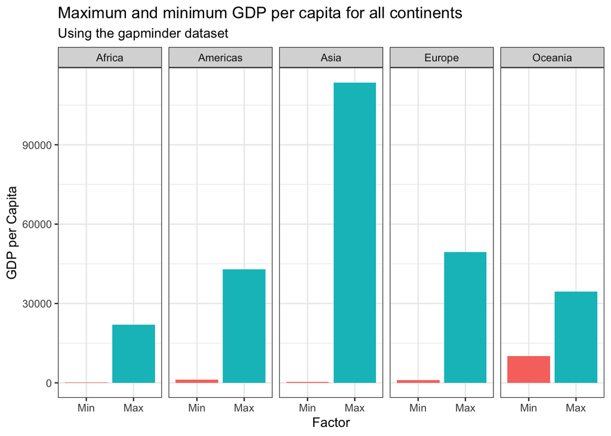

```r
#Melt converts the table from a wide to a tall format to later produce a representative plot to display the data. As a note, I used knitr::kable() prior to this step because I believe the wide format is neater than the tall format for a table.
explore.gdpGapminder %>%
  melt(id.vars = "continent",
       value.name = "gdpPerCap") %>%

#Plotting data with ggplot2. Fill = variable differentially colours each value in the x axis.
  ggplot(aes(x = variable, y = gdpPerCap, fill = variable)) +

  #Included stat = "identity" in response to 'Error: stat_count() must not be used with a y aesthetic' that R was returning if not included.
  geom_bar(stat = "identity") +

  #Splits data by the chosen variable (in this case, the categorical variable 'continent') and plots the subsets of data together. Chose nrow = 1 for a cleaner display (with 2+ rows it was kind of messy because the number of continents is uneven)
  facet_wrap(~ continent, nrow = 1) +

  #Changed X axis variable labels for a neater display, the names 'minGdpPerCap' and 'maxGdpPerCap' were too long. Could have gone back to earlier in the code to do this, but decided to try this function that I hadn't used before!
  scale_x_discrete(labels = c('Min','Max')) +

  #Labelling axes and title
  ylab("GDP per Capita") +
  xlab("Factor") +
  ggtitle("Maximum and minimum GDP per capita for all continents") +

  #Removing legend that was introduced with the fill = variable in line 51 because it is redundant.
  guides(fill = FALSE) +

  #Changing the plot theme from grey to black and white.
  theme_bw() +

  #Adds a subtitle and a caption
  labs(subtitle = "Using the gapminder dataset")
```

### 2.2 **Task Option 5**

How is life expectancy changing over time on different continents?

**Comments about the process**

- [Read](https://garrettgman.github.io/tidying/) about tidying data so that I could transpose the table to a wide format.
- [More](https://www.datanovia.com/en/blog/ggplot-title-subtitle-and-caption/) on how to add + adjust ggplot2 titles, subtitles and caption.

**Comments about table and plot**

- Particularly compared to the gdp per Capita values explored earlier, it is interesting to see that Oceania shows the highest life expectancy in all the recorded years. However, it is also the continent that has the least pronounced increase until the late 70s, earlier than that life expectancy remains pretty consistent at the 70-73 years old mark, meaning that in 37 years (1970 to 2007), life expectancy has increased by about 10 years.
- On the other hand, life expectancy in Africa seems to have had a consistent increase until the late 1980s, and since then it has completely flatlined. It would be intriguing to see newer data, I am curious as to whether it has stayed around the same or it has resumed increasing (or possibly taken any dips)
- I would also be interested in exploring life expectancy data based on female and male gender rather than in the general population, to see the differences between the two by continent.

```r
explore.lifeExp.gapminder <-
  gapminder %>%
  group_by(year, continent) %>%
  summarise(avglifeExp = mean(lifeExp))

#Wide format is neater to present the table, than the tall format above, which is still needed to plot the graph
explore.lifeExp.gapminder_table <-
  explore.lifeExp.gapminder %>%
  spread(year, avglifeExp) %>%
  knitr::kable()

#Visualizing the data
explore.lifeExp.gapminder_table
```

| continent | 1952 | 1957 | 1962 | 1967 | 1972 | 1977 | 1982 | 1987 | 1992 | 1997 | 2002 | 2007 |
| --- | --- | --- | --- | --- | --- | --- | --- | --- | --- | --- | --- | --- |
| Africa | 39.13550 | 41.26635 | 43.31944 | 45.33454 | 47.45094 | 49.58042 | 51.59287 | 53.34479 | 53.62958 | 53.59827 | 53.32523 | 54.80604 |
| Americas | 53.27984 | 55.96028 | 58.39876 | 60.41092 | 62.39492 | 64.39156 | 66.22884 | 68.09072 | 69.56836 | 71.15048 | 72.42204 | 73.60812 |
| Asia | 46.31439 | 49.31854 | 51.56322 | 54.66364 | 57.31927 | 59.61056 | 62.61794 | 64.85118 | 66.53721 | 68.02052 | 69.23388 | 70.72848 |
| Europe | 64.40850 | 66.70307 | 68.53923 | 69.73760 | 70.77503 | 71.93777 | 72.80640 | 73.64217 | 74.44010 | 75.50517 | 76.70060 | 77.64860 |
| Oceania | 69.25500 | 70.29500 | 71.08500 | 71.31000 | 71.91000 | 72.85500 | 74.29000 | 75.32000 | 76.94500 | 78.19000 | 79.74000 | 80.71950 |

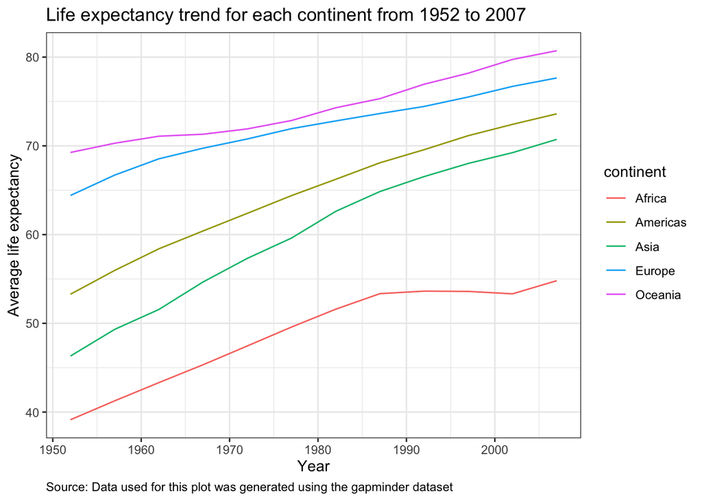

```r
ggplot(explore.lifeExp.gapminder, aes(x = year, y = avglifeExp, color = continent)) +
  geom_line() +
  xlab("Year") +
  ylab("Average life expectancy") +
  ggtitle("Life expectancy trend for each continent from 1952 to 2007") +
  theme_bw() +
  labs(caption = "Source: Data used for this plot was generated using the gapminder dataset") +
  theme(plot.caption = element_text(hjust = 0))
```

### 2.3 **Task Option 4**

Compute a trimmed mean of life expectancy for different years. Or a weighted mean, weighting by population. Just try something other than the plain vanilla mean.

**Comments about the process**

- I found [this](https://garstats.wordpress.com/2017/11/28/trimmed-means/) article explaining trimmed means and their uses very interesting (and useful!)

**Comments about the table and plot**

- Worth pointing out that the increase starts to progress more slowly after 1980, i.e. before that the increase in average life expectancy is fairly sharp.

```r
trimmed.mean <-
gapminder %>%
  group_by(year) %>%
  summarize(avg_lifeExp = mean(lifeExp, trim = .20)) #Standard error of the trimmed mean is less affected by outliers and asymmetry than the mean, so using trimmed means has more statistical power

#Visualizing the data
trimmed.mean %>%
  knitr::kable()
```

| year | avg_lifeExp |
| --- | --- |
| 1952 | 47.74866 |
| 1957 | 50.64422 |
| 1962 | 53.12857 |
| 1967 | 55.63999 |
| 1972 | 58.12370 |
| 1977 | 60.38896 |
| 1982 | 62.47444 |
| 1987 | 64.48383 |
| 1992 | 65.89072 |
| 1997 | 66.84437 |
| 2002 | 67.77385 |
| 2007 | 69.17224 |

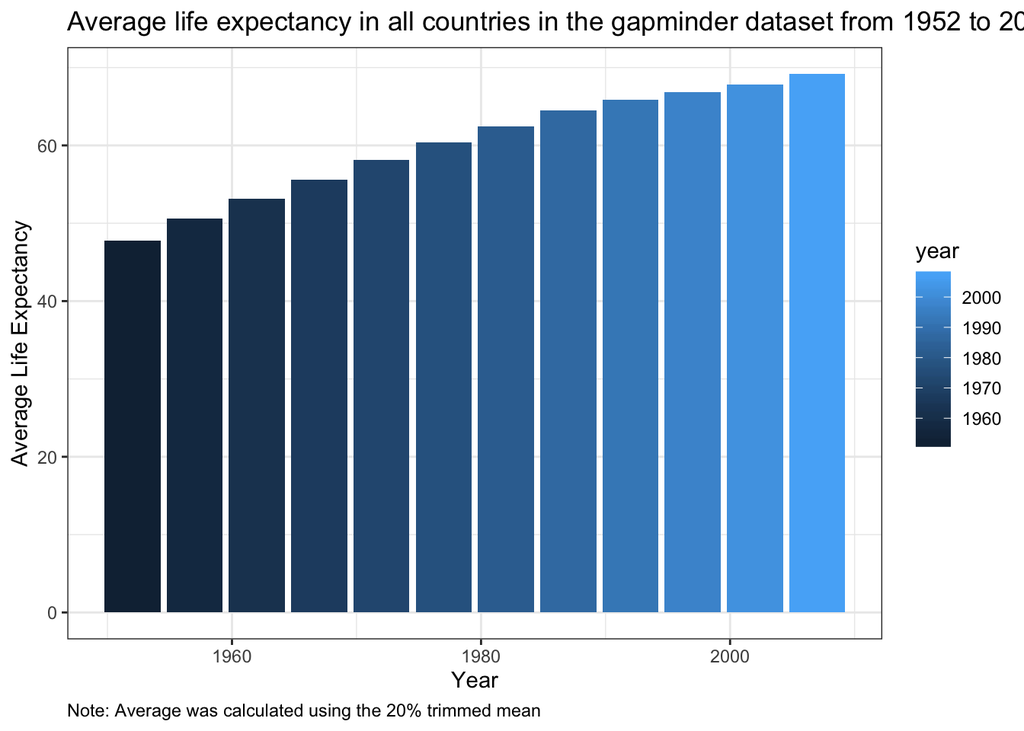

```r
ggplot(trimmed.mean, aes(x = year, y = avg_lifeExp, fill = year)) +
  geom_bar(stat = "identity") +
  theme_bw() +
  ylab("Average Life Expectancy") +
  xlab("Year") +
  ggtitle("Average life expectancy in all countries in the gapminder dataset from 1952 to 2007") +
  labs(caption = "Note: Average was calculated using the 20% trimmed mean") +
  theme(plot.caption = element_text(hjust = 0))
```

**Optional Exercise (2%)** Get table and figure side-by-side. This gist might get you started. https://gist.github.com/jennybc/e9e9aba6ba18c72cec26